# Fed Policy, the Dual Mandate, and Treasury Yield Responses

Yuting Xia

# Question

**Since 2022, did inflation fall without a major deterioration in employment as the Federal Reserve changed rates, and did policy announcements move shorter-maturity Treasury yields more than longer-maturity yields?**

The Federal Reserve pursues price stability and maximum employment, while tighter policy can create a trade-off between them. This analysis follows the policy cycle from inflation and unemployment to the response of 2-, 10-, and 30-year Treasury yields.

```
Official public pages
         |
       rvest
         |
Extract yields, policy events, CPI, and unemployment
         |
Clean dates and numeric fields
         |
Measure yield changes on announcement dates
         |
Three figures + saved results
```

# 1. Choose the public pages

Treasury supplies daily yields, the Federal Reserve supplies policy records, and the Bureau of Labor Statistics supplies monthly CPI and unemployment. The sample cutoff is fixed for reproducibility.

```r
sample_start <- as.Date("2022-01-01")
sample_end <- as.Date("2026-09-19")

treasury_url <- function(year) {
  paste0(
    "https://home.treasury.gov/resource-center/data-chart-center/interest-rates/TextView",
    "?type=daily_treasury_yield_curve&field_tdr_date_value=", year
  )
}
archive_url <- paste0(
  "https://home.treasury.gov/resource-center/data-chart-center/interest-rates/",
  "daily-treasury-rate-archives/par-yield-curve-render-2020-2023.xml"
)
policy_url <- "https://www.federalreserve.gov/monetarypolicy/openmarket.htm"
calendar_url <- "https://www.federalreserve.gov/monetarypolicy/fomccalendars.htm"
unemployment_url <- "https://data.bls.gov/timeseries/LNS14000000"
cpi_url <- "https://data.bls.gov/timeseries/CUSR0000SA0"

treasury_url(2026)
```

```
## [1] "https://home.treasury.gov/resource-center/data-chart-center/interest-rates/TextView?type=daily_treasury_yield_curve&field_tdr_date_value=2026"
```

# 2. Read and preserve the page

`read_html()` retrieves and parses each document. Saved snapshots avoid repeated requests, which are spaced two seconds apart.

```r
read_page <- function(address, filename, format = "HTML") {
  snapshot <- file.path(raw_dir, filename)

  if (file.exists(snapshot)) {
    page <- rvest::read_html(snapshot)
  } else {
    page <- rvest::read_html(url(address, method = "libcurl"))
    xml2::write_html(page, snapshot)
    Sys.sleep(2)
  }

  # Record the source URL and fingerprint of the document actually parsed.
  source_log[[filename]] <<- data.frame(
    source_url = address,
    format = format,
    snapshot = paste0("data/raw/", filename),
    snapshot_sha256 = digest::digest(file = snapshot, algo = "sha256")
  )
  page
}

page <- read_page(treasury_url(2026), "treasury_2026.html")

page |>
  html_element("title") |>
  html_text2()
```

```
## [1] "Daily Treasury Rates | U.S. Department of the Treasury"
```

# 3. Find the yield table

These observations sit in tables. Match column names rather than assuming the first table is correct.

```r
tables <- page |>
  html_elements("table") |>
  html_table(fill = TRUE)

required_columns <- c("Date", "2 Yr", "10 Yr", "30 Yr")
matches <- vapply(
  tables,
  function(table) all(required_columns %in% names(table)),
  logical(1)
)
stopifnot(sum(matches) == 1)

tables[[which(matches)]] |>
  select(all_of(required_columns)) |>
  head()
```

```
## # A tibble: 6 × 4
##   Date       `2 Yr` `10 Yr` `30 Yr`
##   <chr>       <dbl>   <dbl>   <dbl>
## 1 01/02/2026   3.47    4.19    4.86
## 2 01/05/2026   3.46    4.17    4.85
## 3 01/06/2026   3.47    4.18    4.86
## 4 01/07/2026   3.47    4.15    4.82
## 5 01/08/2026   3.49    4.19    4.85
## 6 01/09/2026   3.54    4.18    4.82
```

# 4. Extract the three recent yield series

Repeat the same extraction for 2024–2026. Keep the source document attached to each row.

```r
extract_year <- function(year) {
  filename <- paste0("treasury_", year, ".html")
  page <- read_page(treasury_url(year), filename)
  tables <- html_table(page, fill = TRUE)
  matches <- vapply(tables, function(x) {
    all(required_columns %in% names(x))
  }, logical(1))
  stopifnot(sum(matches) == 1)

  tables[[which(matches)]] |>
    select(all_of(required_columns)) |>
    transmute(
      date = mdy(Date),
      yield_2y_pct = as.character(`2 Yr`),
      yield_10y_pct = as.character(`10 Yr`),
      yield_30y_pct = as.character(`30 Yr`),
      yield_source = paste0("data/raw/", filename)
    )
}

recent_yields <- bind_rows(lapply(2024:2026, extract_year))
head(recent_yields)
```

```
## # A tibble: 6 × 5
##   date       yield_2y_pct yield_10y_pct yield_30y_pct yield_source
##   <date>     <chr>        <chr>         <chr>         <chr>
## 1 2024-01-02 4.33         3.95          4.08          data/raw/treasury_2024.ht…
## 2 2024-01-03 4.33         3.91          4.05          data/raw/treasury_2024.ht…
## 3 2024-01-04 4.38         3.99          4.13          data/raw/treasury_2024.ht…
## 4 2024-01-05 4.4          4.05          4.21          data/raw/treasury_2024.ht…
## 5 2024-01-08 4.36         4.01          4.17          data/raw/treasury_2024.ht…
## 6 2024-01-09 4.36         4.02          4.18          data/raw/treasury_2024.ht…
```

# 5. Add the historical archive

Treasury stores 2022–2023 in a static XML archive, whose named fields require different selectors from recent HTML tables.

```r
archive <- read_page(
  archive_url,
  "treasury_2020_2023_archive.html",
  format = "Static XML archive"
)
entries <- html_elements(archive, "entry")
stopifnot(length(entries) > 0)

archive_field <- function(field_name) {
  entries |>
    html_element(xpath = paste0(".//*[name()='", field_name, "']")) |>
    html_text2()
}

historical_yields <- tibble(
  date = as.Date(substr(archive_field("d:new_date"), 1, 10)),
  yield_2y_pct = archive_field("d:bc_2year"),
  yield_10y_pct = archive_field("d:bc_10year"),
  yield_30y_pct = archive_field("d:bc_30year"),
  yield_source = "data/raw/treasury_2020_2023_archive.html"
)
head(historical_yields)
```

```
## # A tibble: 6 × 5
##   date       yield_2y_pct yield_10y_pct yield_30y_pct yield_source
##   <date>     <chr>        <chr>         <chr>         <chr>
## 1 2020-01-02 1.58         1.88          2.33          data/raw/treasury_2020_20…
## 2 2020-01-03 1.53         1.80          2.26          data/raw/treasury_2020_20…
## 3 2020-01-06 1.54         1.81          2.28          data/raw/treasury_2020_20…
## 4 2020-01-07 1.54         1.83          2.31          data/raw/treasury_2020_20…
## 5 2020-01-08 1.58         1.87          2.35          data/raw/treasury_2020_20…
## 6 2020-01-09 1.58         1.85          2.38          data/raw/treasury_2020_20…
```

# 6. Clean and check the yields

Convert text into dates and numbers without replacing missing values. Yields are percentages, not bond returns.

```r
clean_number <- function(x) {
  x <- str_squish(as.character(x))
  x[x %in% c("", ".", "N/A", "NA")] <- NA_character_
  number <- suppressWarnings(as.numeric(x))
  if (any(!is.na(x) & is.na(number))) stop("Unexpected numeric text.")
  number
}

all_yields <- bind_rows(historical_yields, recent_yields)
stopifnot(!anyNA(all_yields$date), !anyDuplicated(all_yields$date))
yields <- all_yields |>
  filter(date >= sample_start, date <= sample_end) |>
  mutate(across(starts_with("yield_") & ends_with("_pct"), clean_number)) |>
  arrange(date)

yield_checks <- yields |>
  summarise(
    observations = n(),
    first_date = min(date),
    last_date = max(date),
    across(ends_with("_pct"), ~ sum(is.na(.x)), .names = "missing_{.col}")
  )
knitr::kable(yield_checks)
```

| observations | first_date | last_date | missing_yield_2y_pct | missing_yield_10y_pct | missing_yield_30y_pct |
| --- | --- | --- | --- | --- | --- |
| 1178 | 2022-01-03 | 2026-09-18 | 0 | 0 | 0 |

# 7. Extract all policy rate changes

The Fed’s history table gives rate changes and **effective dates**; the preceding heading identifies the year.

```r
policy_page <- read_page(policy_url, "fed_openmarket.html")
policy_tables <- html_elements(policy_page, "table")

extract_changes <- function(table_node) {
  year_text <- table_node |>
    html_element(xpath = "preceding::h4[1]") |>
    html_text2() |>
    str_squish()
  if (is.na(year_text) || !str_detect(year_text, "^20[0-9]{2}$")) return(NULL)
  year <- as.integer(year_text)
  if (year < 2020 || year > lubridate::year(sample_end)) return(NULL)

  table <- html_table(table_node)
  stopifnot(all(c("Date", "Increase", "Decrease", "Level (%)") %in% names(table)))
  bounds <- str_split_fixed(str_replace_all(table$`Level (%)`, "[–—−‑]", "-"), "-", 2)

  tibble(
    effective_date = mdy(paste(table$Date, year)),
    change_bp = clean_number(table$Increase) - clean_number(table$Decrease),
    target_lower_pct = clean_number(bounds[, 1]),
    target_upper_pct = clean_number(bounds[, 2]),
    policy_source = "data/raw/fed_openmarket.html"
  )
}

policy_history <- bind_rows(lapply(policy_tables, extract_changes)) |>
  filter(effective_date <= sample_end, change_bp != 0) |>
  mutate(decision = if_else(change_bp > 0, "Hike", "Cut")) |>
  arrange(effective_date)

changes <- policy_history |>
  filter(effective_date >= sample_start)

stopifnot(!anyNA(changes$effective_date), !anyDuplicated(changes$effective_date),
          !anyNA(changes$change_bp))
knitr::kable(changes |> select(effective_date, decision, change_bp))
```

| effective_date | decision | change_bp |
| --- | --- | --- |
| 2022-03-17 | Hike | 25 |
| 2022-05-05 | Hike | 50 |
| 2022-06-16 | Hike | 75 |
| 2022-07-28 | Hike | 75 |
| 2022-09-22 | Hike | 75 |
| 2022-11-03 | Hike | 75 |
| 2022-12-15 | Hike | 50 |
| 2023-02-02 | Hike | 25 |
| 2023-03-23 | Hike | 25 |
| 2023-05-04 | Hike | 25 |
| 2023-07-27 | Hike | 25 |
| 2024-09-19 | Cut | -50 |
| 2024-11-08 | Cut | -25 |
| 2024-12-19 | Cut | -25 |
| 2025-09-18 | Cut | -25 |
| 2025-10-30 | Cut | -25 |
| 2025-12-11 | Cut | -25 |
| 2026-09-17 | Hike | 25 |

# 8. Find the corresponding announcements

Extract statement links and match each effective date to one preceding statement. The seven-day limit only connects the two official records.

```r
calendar <- read_page(calendar_url, "fed_calendar.html")
links <- calendar |>
  html_elements("a") |>
  html_attr("href")
links <- unique(links[!is.na(links)])
links <- links[str_detect(links, "/pressreleases/monetary[0-9]{8}a\\.htm$")]

statements <- tibble(
  statement_url = xml2::url_absolute(links, calendar_url),
  link_date = ymd(str_extract(links, "[0-9]{8}"))
) |>
  filter(link_date >= sample_start, link_date <= sample_end)

find_statement <- function(effective_date) {
  candidates <- statements |>
    filter(link_date <= effective_date, link_date >= effective_date - 7)
  if (nrow(candidates) != 1) stop("Policy change does not have one matching statement.")
  candidates
}
matched_statements <- bind_rows(lapply(changes$effective_date, find_statement))
changes <- bind_cols(changes, matched_statements)
```

# 9. Read and verify each statement

Read the date printed on the announcement itself and verify whether its text says raise or lower.

```r
read_statement <- function(i) {
  filename <- paste0("fed_statement_", format(changes$link_date[i], "%Y%m%d"), ".html")
  page <- read_page(changes$statement_url[i], filename)

  date_text <- page |>
    html_element(".article__time") |>
    html_text2()
  announcement_date <- mdy(str_squish(date_text))

  paragraphs <- page |>
    html_elements("p") |>
    html_text2() |>
    str_squish()
  action <- paragraphs[str_detect(
    paragraphs, regex("decided to (raise|increase|lower|reduce) the target range", ignore_case = TRUE)
  )]
  if (length(action) != 1) stop("Cannot identify one rate-decision paragraph.")
  action_direction <- if (str_detect(action, "decided to (raise|increase)")) "Hike" else "Cut"
  stopifnot(!is.na(announcement_date), announcement_date == changes$link_date[i],
            action_direction == changes$decision[i])

  tibble(
    announcement_date = announcement_date,
    statement_source = paste0("data/raw/", filename),
    decision_evidence = action
  )
}

verified <- bind_rows(lapply(seq_len(nrow(changes)), read_statement))
events <- bind_cols(changes, verified) |>
  select(announcement_date, effective_date, decision, change_bp,
         target_lower_pct, target_upper_pct, statement_url,
         policy_source, statement_source, decision_evidence) |>
  arrange(announcement_date)

stopifnot(!anyDuplicated(events$announcement_date),
          all(events$announcement_date <= events$effective_date))
knitr::kable(events |> select(announcement_date, effective_date, decision, change_bp))
```

| announcement_date | effective_date | decision | change_bp |
| --- | --- | --- | --- |
| 2022-03-16 | 2022-03-17 | Hike | 25 |
| 2022-05-04 | 2022-05-05 | Hike | 50 |
| 2022-06-15 | 2022-06-16 | Hike | 75 |
| 2022-07-27 | 2022-07-28 | Hike | 75 |
| 2022-09-21 | 2022-09-22 | Hike | 75 |
| 2022-11-02 | 2022-11-03 | Hike | 75 |
| 2022-12-14 | 2022-12-15 | Hike | 50 |
| 2023-02-01 | 2023-02-02 | Hike | 25 |
| 2023-03-22 | 2023-03-23 | Hike | 25 |
| 2023-05-03 | 2023-05-04 | Hike | 25 |
| 2023-07-26 | 2023-07-27 | Hike | 25 |
| 2024-09-18 | 2024-09-19 | Cut | -50 |
| 2024-11-07 | 2024-11-08 | Cut | -25 |
| 2024-12-18 | 2024-12-19 | Cut | -25 |
| 2025-09-17 | 2025-09-18 | Cut | -25 |
| 2025-10-29 | 2025-10-30 | Cut | -25 |
| 2025-12-10 | 2025-12-11 | Cut | -25 |
| 2026-09-16 | 2026-09-17 | Hike | 25 |

# 10. Extract inflation and unemployment

Convert the monthly, seasonally adjusted CPI index into a 12-month percentage change, then compare it with unemployment.

```r
extract_bls_series <- function(address, filename, value_name) {
  page <- read_page(address, filename)
  tables <- html_table(page, fill = TRUE)
  matches <- vapply(tables, function(table) {
    all(c("Year", month.abb) %in% names(table))
  }, logical(1))
  stopifnot(sum(matches) == 1)

  table <- tables[[which(matches)]] |>
    select(Year, all_of(month.abb)) |>
    filter(str_detect(as.character(Year), "^[0-9]{4}$")) |>
    pivot_longer(all_of(month.abb), names_to = "month", values_to = "raw_value") |>
    mutate(
      date = make_date(as.integer(Year), match(month, month.abb), 1L),
      value = as.numeric(str_extract(str_squish(as.character(raw_value)),
                                     "^[0-9]+(?:\\.[0-9]+)?"))
    ) |>
    select(date, value)

  names(table)[2] <- value_name
  table
}

cpi <- extract_bls_series(cpi_url, "bls_cpi.html", "cpi_index") |>
  arrange(date) |>
  mutate(inflation_yoy_pct = 100 * (cpi_index / lag(cpi_index, 12) - 1))

unemployment <- extract_bls_series(
  unemployment_url,
  "bls_unemployment.html",
  "unemployment_pct"
)

macro <- full_join(cpi, unemployment, by = "date") |>
  filter(date >= sample_start, date <= sample_end) |>
  arrange(date)
last_macro_date <- macro |>
  filter(!is.na(inflation_yoy_pct) | !is.na(unemployment_pct)) |>
  summarise(last_date = max(date)) |>
  pull(last_date)
macro <- macro |>
  filter(date <= last_macro_date)

macro_checks <- macro |>
  summarise(
    observations = n(),
    first_date = min(date),
    last_date = max(date),
    missing_inflation = sum(is.na(inflation_yoy_pct)),
    missing_unemployment = sum(is.na(unemployment_pct))
  )
knitr::kable(macro_checks)
```

| observations | first_date | last_date | missing_inflation | missing_unemployment |
| --- | --- | --- | --- | --- |
| 56 | 2022-01-01 | 2026-08-01 | 1 | 1 |

# 12. Combine daily yields with policy markers

Join on announcement dates. Empty event fields mean no rate-change announcement that day.

```r
stopifnot(all(events$announcement_date %in% yields$date))
daily <- yields |>
  left_join(events, by = c("date" = "announcement_date")) |>
  arrange(date)
stopifnot(nrow(daily) == nrow(yields), sum(!is.na(daily$decision)) == nrow(events))

knitr::kable(
  daily |>
    filter(!is.na(decision)) |>
    select(date, yield_2y_pct, yield_10y_pct, yield_30y_pct, decision, change_bp) |>
    head(8)
)
```

| date | yield_2y_pct | yield_10y_pct | yield_30y_pct | decision | change_bp |
| --- | --- | --- | --- | --- | --- |
| 2022-03-16 | 1.95 | 2.19 | 2.46 | Hike | 25 |
| 2022-05-04 | 2.66 | 2.93 | 3.01 | Hike | 50 |
| 2022-06-15 | 3.20 | 3.33 | 3.39 | Hike | 75 |
| 2022-07-27 | 2.96 | 2.78 | 3.03 | Hike | 75 |
| 2022-09-21 | 4.02 | 3.51 | 3.50 | Hike | 75 |
| 2022-11-02 | 4.61 | 4.10 | 4.15 | Hike | 75 |
| 2022-12-14 | 4.23 | 3.49 | 3.52 | Hike | 50 |
| 2023-02-01 | 4.09 | 3.39 | 3.55 | Hike | 25 |

# 13. Calculate announcement-day yield changes

Subtract the previous Treasury observation and multiply by 100 to express each announcement-day change in basis points.

```r
yield_changes <- yields |>
  arrange(date) |>
  mutate(
    change_2y_bp = 100 * (yield_2y_pct - lag(yield_2y_pct)),
    change_10y_bp = 100 * (yield_10y_pct - lag(yield_10y_pct)),
    change_30y_bp = 100 * (yield_30y_pct - lag(yield_30y_pct))
  )

event_moves <- events |>
  select(announcement_date, decision, policy_change_bp = change_bp) |>
  left_join(yield_changes, by = c("announcement_date" = "date")) |>
  pivot_longer(
    cols = c(change_2y_bp, change_10y_bp, change_30y_bp),
    names_to = "tenor",
    values_to = "yield_change_bp"
  ) |>
  mutate(
    tenor = factor(
      tenor,
      levels = c("change_2y_bp", "change_10y_bp", "change_30y_bp"),
      labels = c("2-year", "10-year", "30-year")
    ),
    absolute_change_bp = abs(yield_change_bp)
  )

response_summary <- event_moves |>
  group_by(tenor) |>
  summarise(
    meetings = n(),
    mean_absolute_change_bp = mean(absolute_change_bp, na.rm = TRUE),
    median_absolute_change_bp = median(absolute_change_bp, na.rm = TRUE),
    maximum_absolute_change_bp = max(absolute_change_bp, na.rm = TRUE),
    .groups = "drop"
  )

stopifnot(!anyNA(event_moves$yield_change_bp))
knitr::kable(response_summary, digits = 1)
```

| tenor | meetings | mean_absolute_change_bp | median_absolute_change_bp | maximum_absolute_change_bp |
| --- | --- | --- | --- | --- |
| 2-year | 18 | 8.7 | 7.0 | 25 |
| 10-year | 18 | 6.4 | 5.0 | 16 |
| 30-year | 18 | 3.9 | 2.5 | 10 |

# 14. Graphic 2: Yield levels across the policy cycle

Three curves show daily yield levels. Vertical lines mark announcements; the top labels show the policy adjustment in basis points.

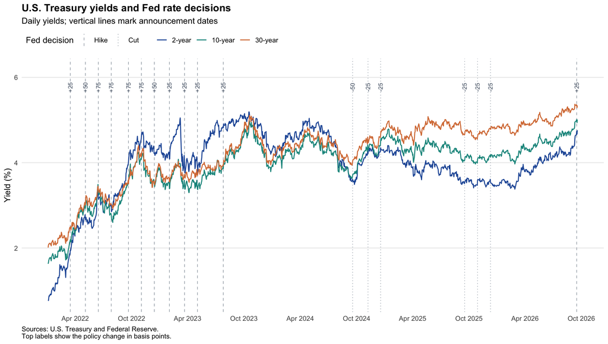

```r
long <- yields |>
  pivot_longer(ends_with("_pct"), names_to = "tenor", values_to = "yield_pct") |>
  mutate(tenor = factor(tenor,
    levels = c("yield_2y_pct", "yield_10y_pct", "yield_30y_pct"),
    labels = c("2-year", "10-year", "30-year")))
markers <- events |>
  mutate(label = sprintf("%+d", as.integer(change_bp)),
         decision = factor(decision, levels = c("Hike", "Cut")))
top <- max(long$yield_pct, na.rm = TRUE)

yield_plot <- ggplot(long, aes(date, yield_pct, colour = tenor)) +
  geom_vline(data = markers,
    aes(xintercept = announcement_date, linetype = decision),
    colour = "#A4ACB5", linewidth = 0.4) +
  geom_line(linewidth = 0.65, na.rm = TRUE) +
  geom_text(data = markers,
    aes(x = announcement_date, y = top + 0.4, label = label),
    inherit.aes = FALSE, angle = 90, size = 3, colour = "#546274") +
  scale_colour_manual(values = c("#2459A6", "#15958C", "#D77C43")) +
  scale_linetype_manual(values = c(Hike = "dashed", Cut = "dotted")) +
  scale_x_date(date_breaks = "6 months", date_labels = "%b %Y") +
  scale_y_continuous(limits = c(NA, top + 0.8)) +
  labs(title = "U.S. Treasury yields and Fed rate decisions",
    subtitle = "Daily yields; vertical lines mark announcement dates",
    x = NULL, y = "Yield (%)", colour = NULL, linetype = "Fed decision",
    caption = paste0("Sources: U.S. Treasury and Federal Reserve.\n",
      "Top labels show the policy change in basis points.")) +
  theme_minimal(base_size = 12) +
  theme(legend.position = "top", legend.justification = "left",
        panel.grid.minor = element_blank(), panel.grid.major.x = element_blank(),
        plot.title = element_text(face = "bold"),
        plot.caption = element_text(hjust = 0))

ggsave(file.path(result_dir, "daily_yields_with_events.png"), yield_plot,
       width = 14, height = 7.4, dpi = 160, bg = "white")
if (knitr::is_html_output()) print(yield_plot)
```

During the 2022–2023 tightening cycle, all three yields rose, but the 2-year yield increased most sharply and spent much of the period above the longer yields. That inversion indicates that investors expected tight policy to weigh on future growth and rates. During the later cutting cycle, the 2-year yield declined more than the 10- and 30-year yields, while the long end remained comparatively elevated.